# 440 Reproducibility and Statistics Assignment Homework

First we need to load the data.

```r
pols<-read.csv("politics.csv")
```

Let’s take a look at the data.

```r
str(pols)
```

```
## 'data.frame':    132 obs. of  7 variables:
##  $ subject      : int  1 2 3 4 5 6 7 8 9 10 ...
##  $ party        : Factor w/ 3 levels "democrat","independent",..: 3 3 2 2 2 3 3 2 3 2 ...
##  $ testtime     : Factor w/ 2 levels "post","pre": 2 2 2 2 2 2 2 2 2 2 ...
##  $ optimismscore: int  52 51 69 51 61 31 57 48 42 64 ...
##  $ minwage      : Factor w/ 2 levels "no","yes": 1 1 2 1 2 1 1 1 1 1 ...
##  $ sex          : Factor w/ 2 levels "female","male": 2 2 1 2 2 2 2 2 2 2 ...
##  $ income       : num  37.3 42.3 73 33.8 57.3 ...
```

Now we need to make sure subject, party, testtime, minwage, and sex are factors. Optimismscore and income should be integer and numeric vectors. So let’s fix those real quick.

```r
pols$subject<-factor(pols$subject)
pols$testtime<-factor(pols$testtime, levels=c("pre", "post"))
```

Okay lets double check the information to make sure our factors changed

```r
str(pols)
```

```
## 'data.frame':    132 obs. of  7 variables:
##  $ subject      : Factor w/ 66 levels "1","2","3","4",..: 1 2 3 4 5 6 7 8 9 10 ...
##  $ party        : Factor w/ 3 levels "democrat","independent",..: 3 3 2 2 2 3 3 2 3 2 ...
##  $ testtime     : Factor w/ 2 levels "pre","post": 1 1 1 1 1 1 1 1 1 1 ...
##  $ optimismscore: int  52 51 69 51 61 31 57 48 42 64 ...
##  $ minwage      : Factor w/ 2 levels "no","yes": 1 1 2 1 2 1 1 1 1 1 ...
##  $ sex          : Factor w/ 2 levels "female","male": 2 2 1 2 2 2 2 2 2 2 ...
##  $ income       : num  37.3 42.3 73 33.8 57.3 ...
```

We will also find the variance.

```r
var(pols$optimism[(pols$testtime="post")])
```

```
## [1] NA
```

Let’s see how posttest optimism scores are distributed. To do this we will creat a histogram.

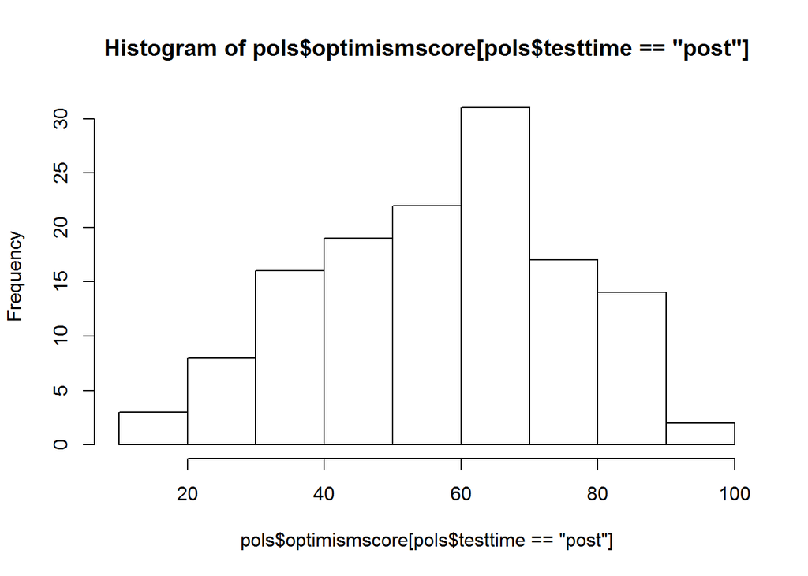

```r
hist(pols$optimismscore[pols$testtime=="post"])
```

```r
tab<-table(pols$party,pols$sex)
tab
```

```
##
##               female male
##   democrat        28   24
##   independent     14   20
##   republican      24   22
```

Great, now lets run the Chi-Square test.

```r
chisq.test(pols$party,pols$sex)
```

```
##
##  Pearson's Chi-squared test
##
## data:  pols$party and pols$sex
## X-squared = 1.4535, df = 2, p-value = 0.4835
```

Now let’s see whether or not males and females have different incomes. To do this we can run an independent t-test.

```r
t.test(pols$income[pols$sex=="male"],pols$income[pols$sex=="female"],paired=FALSE,var.equal=FALSE,alternative="two.sided",con.level=.95)
```

```
##
##  Welch Two Sample t-test
##
## data:  pols$income[pols$sex == "male"] and pols$income[pols$sex == "female"]
## t = -2.2395, df = 125.17, p-value = 0.02689
## alternative hypothesis: true difference in means is not equal to 0
## 95 percent confidence interval:
##  -15.9467513  -0.9844337
## sample estimates:
## mean of x mean of y
##  38.80751  47.27310
```

To create the figure, I need to include the dplyr library. Then I’ll use it to summarize the politics data set and find the means and standard errors for the different conditions. Then I’ll need the ggplot2 library to create a nice plot that’s easy to work with. I’ll do the same thing for any other graphs I create unless I specify otherwise.

```r
library("dplyr")
```

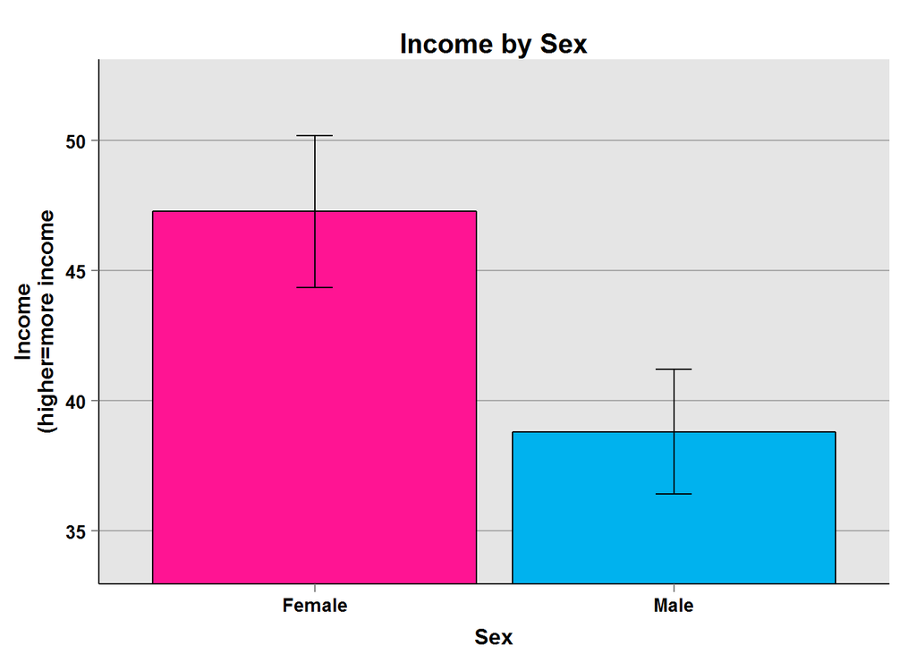

```r
temp<-pols[pols$testtime=="post",]%>%group_by(sex)%>%summarize(means=mean(income),
              sems=sd(income)/sqrt(length(income)))
library("ggplot2")
f<-ggplot(temp,aes(x=factor(sex),y=means))+
    geom_bar(stat="identity", color="black",fill=c("deeppink","deepskyblue2"))+
    geom_errorbar(aes(ymax=means+sems, ymin=means-sems), width=.1)
f<-f+ggtitle("Income by Sex")+
    labs(x="Sex", y="Income\n(higher=more income")+
    scale_x_discrete(breaks=c("female","male"),labels=c("Female","Male"))+
    theme(plot.title=element_text(size=15,face="bold",vjust=.5))+
    theme(axis.title.x=element_text(size=12,face="bold",vjust=-.25))+
    theme(axis.title.y=element_text(size=12,face="bold",vjust=1))+
    theme(axis.text.x=element_text(size=10,face="bold",color="black"))+
    theme(axis.text.y=element_text(size=10,face="bold",color="black"))+
    coord_cartesian(ylim=c(min(temp$means)-2*max(temp$sems),max(temp$means)+2*max(temp$sems)))+
    theme(panel.border=element_blank(), axis.line=element_line())+
    theme(panel.grid.major.x=element_blank())+
    theme(panel.grid.major.y=element_line(color="darkgrey"))+
    theme(panel.grid.minor.y=element_blank())
f
```

Let’s see if party affiliation and sex predict posttest optimism scores independently or in an interaction using a 2-way between-subjects ANOVA.

```r
summary(aov(optimismscore~party*sex,data=pols[pols$testtime=="post",]))
```

```
##              Df Sum Sq Mean Sq F value Pr(>F)
## party         2  21950   10975  61.435 <2e-16 ***
## sex           1     26      26   0.147  0.702
## party:sex     2    667     333   1.866  0.159
## Residuals   126  22509     179
## ---
## Signif. codes:  0 '***' 0.001 '**' 0.01 '*' 0.05 '.' 0.1 ' ' 1
```

To create the plot and manually adjust the fill, I need to use hexadecimal color codes. To convert the named colors I like to hexadecimal, I need to use the gplots library.

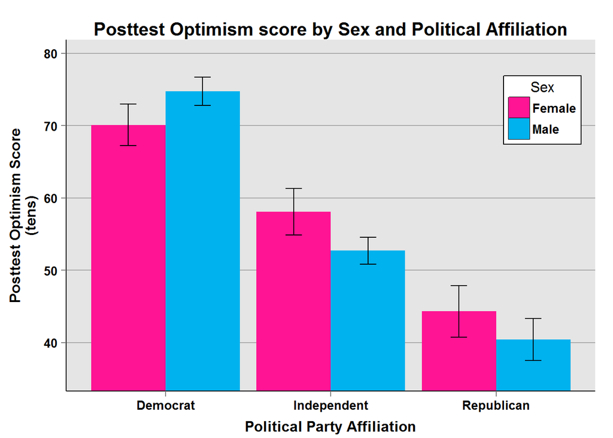

```r
temp<-pols[pols$testtime=="post",]%>%group_by(party,sex)%>%
    summarize(means=mean(optimismscore),sems=sd(optimismscore)/sqrt(length(optimismscore)))
library("gplots")
col1=col2hex("deeppink")
col2=col2hex("deepskyblue2")
f<-ggplot(temp, aes(x=party, y=means, fill=sex))+
    geom_bar(stat="identity",position=position_dodge())+
    scale_fill_manual(values=c(col1,col2),name="Sex",breaks=c("female","male"),labels=c("Female", "Male"))+
    theme(legend.key=element_rect(color="black"))+
    geom_errorbar(aes(ymax=means+sems, ymin=means-sems),width=.2,position=position_dodge(.9))+
    ggtitle("Posttest Optimism score by Sex and Political Affiliation")+
    labs(x="Political Party Affiliation",y="Posttest Optimism Score\n(tens)")+
    scale_x_discrete(breaks=c("democrat","independent","republican"),labels=c("Democrat","Independent","Republican"))+
    theme(plot.title=element_text(size=15,face="bold",vjust=.5))+
    theme(axis.title.x=element_text(size=12,face="bold",vjust=-.25))+
    theme(axis.title.y=element_text(size=12,face="bold",vjust=1))+
    theme(axis.text.x=element_text(size=10,face="bold",color="black"))+
    theme(axis.text.y=element_text(size=10,face="bold",color="black"))+
    coord_cartesian(ylim=c(min(temp$means)-2*max(temp$sems),max(temp$means)+2*max(temp$sems)))+
    theme(panel.border=element_blank(),axis.line=element_line())+
    theme(panel.grid.major.x=element_blank())+
    theme(panel.grid.major.y=element_line(color="darkgrey"))+
    theme(panel.grid.minor.y=element_blank())+
    theme(legend.position=c(.9,.80))+
    theme(legend.background=element_blank())+
    theme(legend.background=element_rect(color="black"))+
    theme(legend.title=element_blank())+
    theme(legend.title=element_text(size=12))+
    theme(legend.title.align=.5)+
    theme(legend.text=element_text(size=10,face="bold"))
f
```

Now we will create a line graph for extra practice.

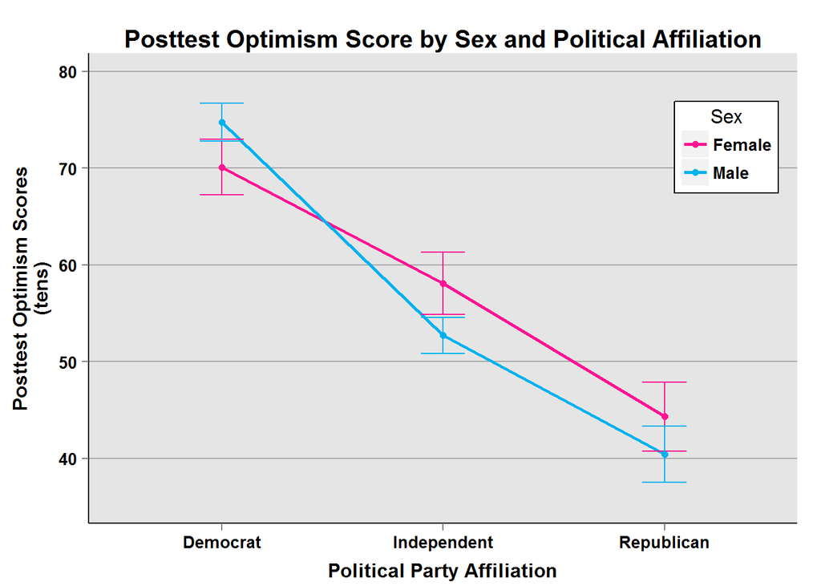

```r
f<-ggplot(temp, aes(x=party, y=means, group=sex, color=sex))+
    geom_line(size=1)+
    geom_point(size=2)+
    scale_color_manual(values=c(col1,col2),name="Sex",breaks=c("female","male"),labels=c("Female", "Male"))+
    geom_errorbar(aes(ymax=means+sems, ymin=means-sems),width=.2)+
    ggtitle("Posttest Optimism Score by Sex and Political Affiliation")+
    labs(x="Political Party Affiliation",y="Posttest Optimism Scores\n(tens)")+
    scale_x_discrete(breaks=c("democrat","independent","republican"),labels=c("Democrat","Independent","Republican"))+
    theme(plot.title=element_text(size=15,face="bold",vjust=.5))+
    theme(axis.title.x=element_text(size=12,face="bold",vjust=-.25))+
    theme(axis.title.y=element_text(size=12,face="bold",vjust=1))+
    theme(axis.text.x=element_text(size=10,face="bold",color="black"))+
    theme(axis.text.y=element_text(size=10,face="bold",color="black"))+
    coord_cartesian(ylim=c(min(temp$means)-2*max(temp$sems),max(temp$means)+2*max(temp$sems)))+
    theme(panel.border=element_blank(),axis.line=element_line())+
    theme(panel.grid.major.x=element_blank())+
    theme(panel.grid.major.y=element_line(color="darkgrey"))+
    theme(panel.grid.minor.y=element_blank())+
    theme(legend.position=c(.9,.80))+
    theme(legend.background=element_blank())+
    theme(legend.background=element_rect(color="black"))+
    theme(legend.title=element_blank())+
    theme(legend.title=element_text(size=12))+
    theme(legend.title.align=.5)+
    theme(legend.text=element_text(size=10,face="bold"))
f
```

*Fin*